# ExtraaLearn Project

##### Plotting the Distribution of Categorical Variables

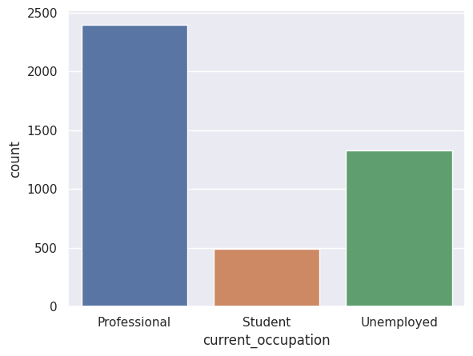

```
 Professional    0.568683
Unemployed      0.315540
Student         0.115777
Name: current_occupation, dtype: float64
```

```python
sns.countplot(x=df['current_occupation'])
plt.show()
print('\n',df['current_occupation'].value_counts(normalize=True))
```

- Over 50% of the sample is made up of Professionals

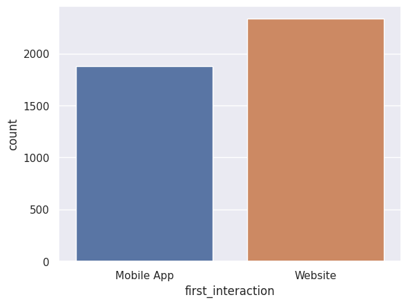

```
 Website       0.554211
Mobile App    0.445789
Name: first_interaction, dtype: float64
```

```python
sns.countplot(x = df['first_interaction'])
plt.show()
print('\n',df['first_interaction'].value_counts(normalize=True))
```

- 55% of first interactions is through the website, which is important to consider if we want to improve the first interactions with leads

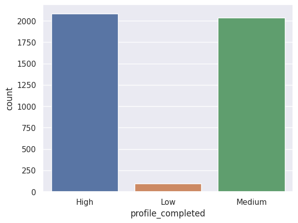

```
 High      0.494425
Medium    0.482562
Low       0.023013
Name: profile_completed, dtype: float64
```

```python
sns.countplot(x = df['profile_completed'])
plt.show()
print('\n',df['profile_completed'].value_counts(normalize=True))
```

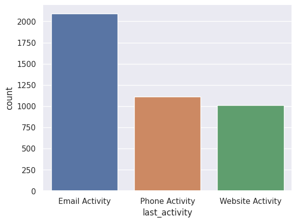

```
 Email Activity      0.496323
Phone Activity      0.264294
Website Activity    0.239383
Name: last_activity, dtype: float64
```

```python
sns.countplot(x=df['last_activity'])
plt.show()
print('\n',df['last_activity'].value_counts(normalize=True))
```

- Almost half of leads engage with the company via Email communication

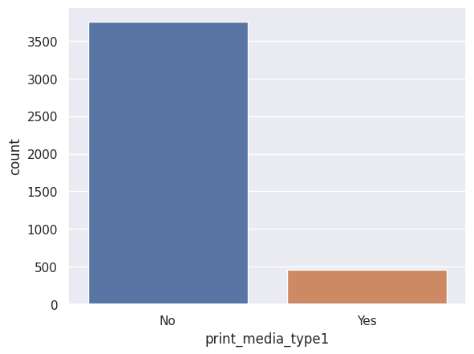

```
 No     0.891578
Yes    0.108422
Name: print_media_type1, dtype: float64
```

```python
sns.countplot(x = df['print_media_type1'])
plt.show()
print('\n',df['print_media_type1'].value_counts(normalize=True))
```

- About 11% of leads encountered ads through Newspaper

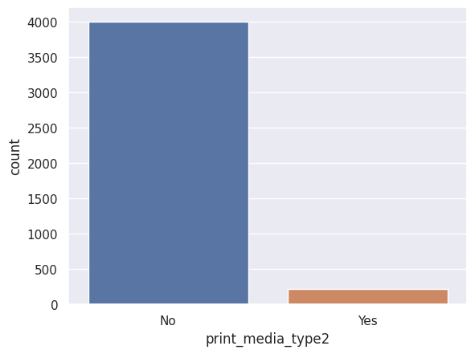

```
 No     0.948754
Yes    0.051246
Name: print_media_type2, dtype: float64
```

```python
sns.countplot(x=df['print_media_type2'])
plt.show()
print('\n',df['print_media_type2'].value_counts(normalize=True))
```

- About 5% of leads saw an ad in Magazines

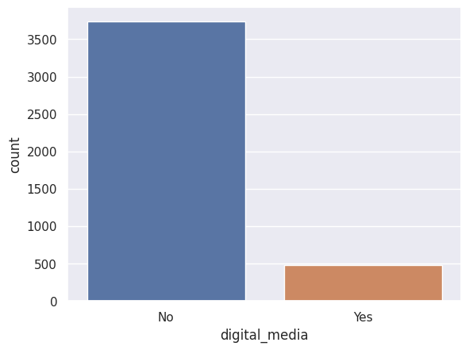

```
 No     0.88707
Yes    0.11293
Name: digital_media, dtype: float64
```

```python
sns.countplot(x=df['digital_media'])
plt.show()
print('\n',df['digital_media'].value_counts(normalize=True))
```

- About 11% of leads saw an ad through digital media channels

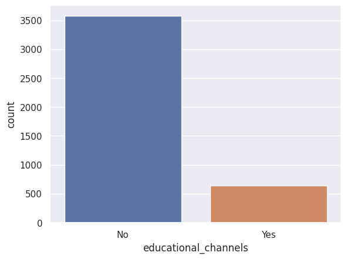

```
 No     0.848873
Yes    0.151127
Name: educational_channels, dtype: float64
```

```python
sns.countplot(x=df['educational_channels'])
plt.show()
print('\n',df['educational_channels'].value_counts(normalize=True))
```

- About 15% of leads encountered ads in educational channels

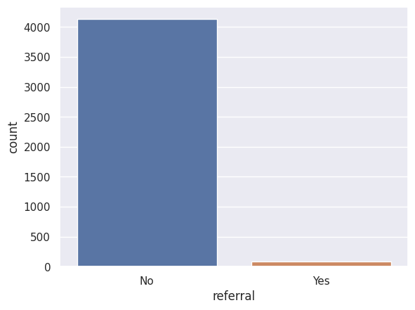

```
 No     0.980308
Yes    0.019692
Name: referral, dtype: float64
```

```python
sns.countplot(x=df['referral'])
plt.show()
print('\n',df['referral'].value_counts(normalize=True))
```

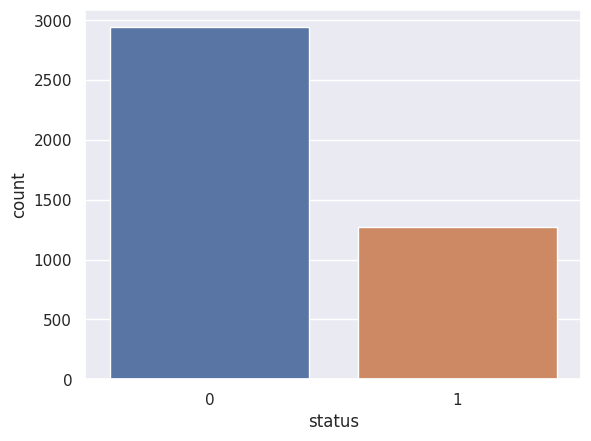

```
 0    0.697746
1    0.302254
Name: status, dtype: float64
```

```python
sns.countplot(x=df['status'])
plt.show()
print('\n',df['status'].value_counts(normalize=True))
```

#### BiVariate Analysis

##### Continuous Variables

```python
# Using a heatmap to determine the correlation between continuous variables

cols_list = df.select_dtypes(include=np.number).columns.tolist()

plt.figure(figsize=(12, 7))
sns.heatmap(data[cols_list].corr(), annot=True, vmin=-1, vmax=1, fmt=".2f", cmap="Spectral")
plt.show()
```

[output not shown]

```python
# Using a heatmap to determine the correlation between continuous variables

cols_list = df2.select_dtypes(include=np.number).columns.tolist()

plt.figure(figsize=(12, 7))
sns.heatmap(data[cols_list].corr(), annot=True, vmin=-1, vmax=1, fmt=".2f", cmap="Spectral")
plt.show()
```

[output not shown]

```python
print(df.count())
```

```
age                      4215
current_occupation       4215
first_interaction        4215
profile_completed        4215
website_visits           4215
time_spent_on_website    4215
page_views_per_visit     4215
last_activity            4215
print_media_type1        4215
print_media_type2        4215
digital_media            4215
educational_channels     4215
referral                 4215
status                   4215
dtype: int64
```

```python
print(df2.count())
```

```
age                      4612
current_occupation       4612
first_interaction        4612
profile_completed        4612
website_visits           4612
time_spent_on_website    4612
page_views_per_visit     4612
last_activity            4612
print_media_type1        4612
print_media_type2        4612
digital_media            4612
educational_channels     4612
referral                 4612
status                   4612
dtype: int64
```

##### Categorical Variables

```python
# Define the stacked barplot function

def stacked_barplot(data, predictor, target, figsize=(5, 3)):
    # Create a crosstab with percentages
    crosstab = (pd.crosstab(data[predictor], data[target], normalize='index') * 100)

    # Create the stacked barplot
    ax = crosstab.plot(kind='bar', figsize=figsize, stacked=True)

    # Add percentage labels on top of the bars
    for container in ax.containers:
        ax.bar_label(container, fmt='%.2f%%', label_type='edge', fontsize = 7)

    plt.legend(loc='lower right')
    plt.ylabel(target)
    plt.show()
```

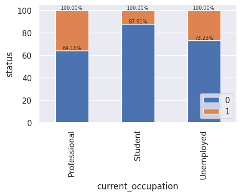

```python
stacked_barplot(df,"current_occupation","status")
```

- Professionals had the highest conversion rate confirming that users of the product likely have a higher spending capacity to pay for it. This also tells us that it will be important for marketing materials to highlight that it is designed to be done at the same time as a full time job
- Unemployed professionals had the second highest conversion rate, which indicates that the program should also explain the benefits to securing a new position in the area of interest
- Students had the lowest conversion rate

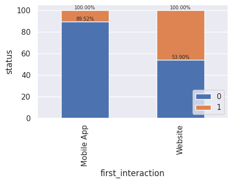

```python
stacked_barplot(df,"first_interaction","status")
```

- Leads with the website as the first interaction had the highest conversion rate
  - this is positive considering that a higher percentage of leads interacted with the website first
  - the low conversion rate (around 10%) on the Mobile App indicates need for improvement on the Mobile App experience and marketing materials as 45% of the sample had a first impression on the app

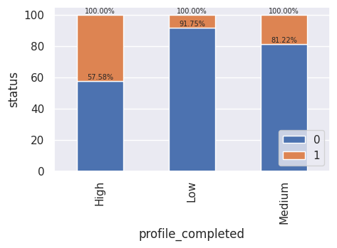

```python
stacked_barplot(df,"profile_completed","status")
```

- Leads that had high profile completion had the highest conversion rate, which can indicate that investing in adding personal data to the profile is related to the seriousness of the lead
- Low and Medium profile completions had low conversion rates, which may indicate that there is critical information that these leads are not receiving that could lead to conversions due to the lack of a complete profile

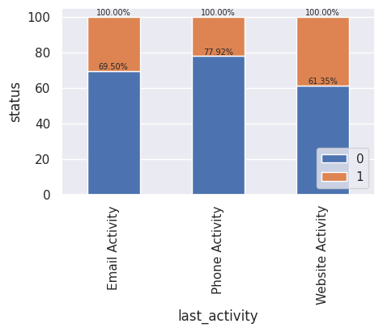

```python
stacked_barplot(df,"last_activity","status")
```

- Website Activity had the highest conversion rate despite being the channel that had the least amount of observations in the sample
  - the live chat feature may be driving conversion as questions are resolved in real-time
  - further investigation could be done to understand why email and phone activity, which have higher number of observations are not driving more conversions

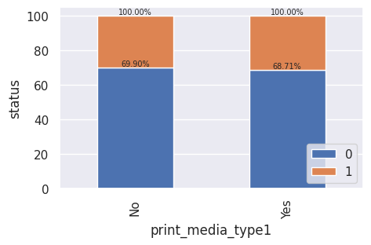

```python
stacked_barplot(df,"print_media_type1","status")
```

- Interaction with Newspaper Ads does not seem to be a big factor in determining conversion as the rates are similar for both categories
- This is one of the channels with higher impressions so it could be further analyzed and improved - though there is a lightly higher percent of conversions from these ads

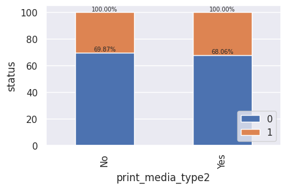

```python
stacked_barplot(df,"print_media_type2","status")
```

- Similar to Newspaper Ads, Magazine ads do not seem to be a key driver in conversions
- This was the channel with the lowest impressions, however, it was the channel that had the highest conversion rate (except for referrals)

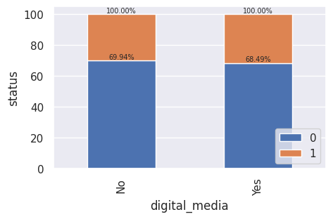

```python
stacked_barplot(df,"digital_media","status")
```

- Digital media channel also does not seem to be driving conversions
- There is still the opporuntity to drive higher volume of impressions with links as it is currently on par with Newspaper ads in impressions which could lead to more conversion as this channel is further developed

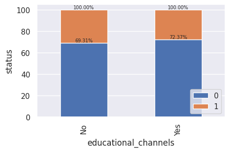

```python
stacked_barplot(df,"educational_channels","status")
```

- Educational channels also does not seem to be a critical factor in driving conversions, and in fact, the % of conversions is lower for the leads generated through this channel
- The educational channels used needs to be reviewed as this channel drove the most impressions, but fails to increase conversions

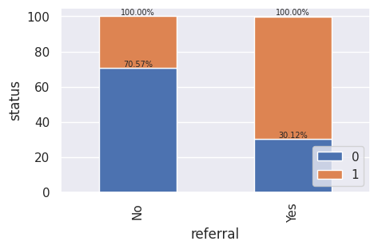

```python
stacked_barplot(df,"referral","status")
```

- As hypothesized, referrals seem to have the highest conversion rates
- This may be affected as there are less observations in this sample, however, as mentioned it represents a great opportunity for the organization

##### Observations

Completed a second round of EDA after manipulating data for Model Readiness. All trends from the original EDA hold true - outliers were fully removed from website visits. Most outliers removed from average page visits.

Even after outliers were removed, the Bivariate Analysis showed that continuous variables maintained the same correlations and were not significantly affected by the removal. Some percent changes were seen in the categorical variables but not material to show changes in the trends.

## Building a Decision Tree model

#### Model Evaluation Criteria

There are two ways the model can be wrong:

1. The model can predict that the lead will convert, but the lead will not convert (False Positive)
   - The risk is dedicating company resources to a potential customer that will not be converted
2. The model can predict that the lead will not covert, but the lead would convert (False Negative)
   - The risk is missing out on a potential paying customer

**In this case, the company is looking to maximize `Recall`, since missing out on a potential customer is greater than the risk of dedicating resources for lead conversion** Even if the targeted customer is not converted, the resources for conversion might work on additional customers.

```python
# Creating a metric function to measure and maximize the possibility of recall

def metrics_score(actual,predicted):
  print(classification_report(actual, predicted))

  cm = confusion_matrix(actual, predicted)
  plt.figure(figsize=(8,5))

  sns.heatmap(cm, annot=True, fmt='.2f')
  plt.ylabel('Actual')
  plt.xlabel('Predicted')
  plt.show()
```

##### Building the Decision Tree

```python
model_dt = DecisionTreeClassifier(random_state=1)
model_dt.fit(X_train, y_train)
```

```
DecisionTreeClassifier(random_state=1)
```

```
              precision    recall  f1-score   support

         0.0       1.00      1.00      1.00      2058
         1.0       1.00      1.00      1.00       892

    accuracy                           1.00      2950
   macro avg       1.00      1.00      1.00      2950
weighted avg       1.00      1.00      1.00      2950
```

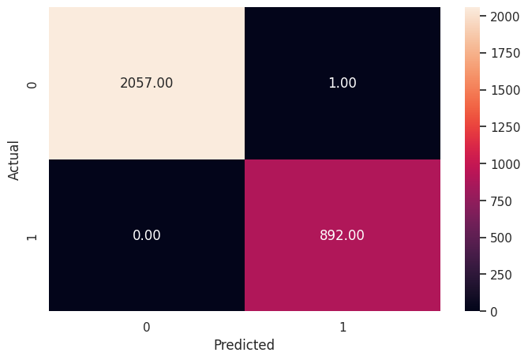

```python
# Evaluating the performance on the training dataset

pred_train_dt = model_dt.predict(X_train)
metrics_score(y_train, pred_train_dt)
```

- There appears to only be 1 error on the training dataset, and this error is a False Positive
- Since we are looking to maximize recall, which is only affected by False Negatives, we see 100% recall indicating that the model has performed very well on the training data that is was built on
- There is a high risk that the model is overfitting to the training data, which we will measure against the test data

```
              precision    recall  f1-score   support

         0.0       0.86      0.83      0.84       883
         1.0       0.64      0.69      0.66       382

    accuracy                           0.79      1265
   macro avg       0.75      0.76      0.75      1265
weighted avg       0.79      0.79      0.79      1265
```

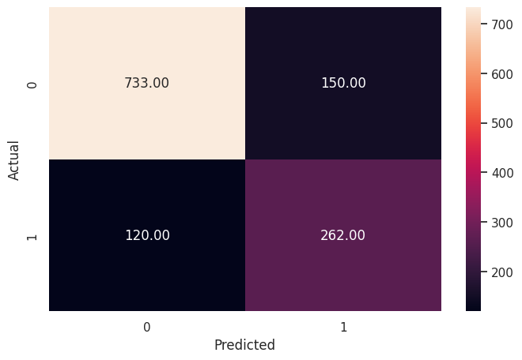

```python
# Evaluating performance against the test data

pred_test_dt = model_dt.predict(X_test)
metrics_score(y_test, pred_test_dt)
```

- The model is in fact overfitting, but it has still performed well in recall with 69%
- We can try to make the model better by tuning the tree to reduce the effects of overfitting

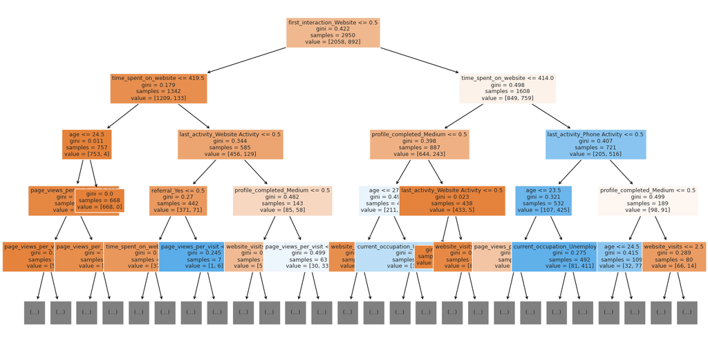

```python
# Visualizing the Pruned Decision Tree

feature_names = list(X_train.columns)
plt.figure(figsize=(20, 10))
out = tree.plot_tree(
    model_dt,
    max_depth=4,
    feature_names=feature_names,
    filled=True,
    fontsize=9,
    node_ids=False,
    class_names=None,
)
# below code will add arrows to the decision tree split if they are missing
for o in out:
    arrow = o.arrow_patch
    if arrow is not None:
        arrow.set_edgecolor("black")
        arrow.set_linewidth(1)
plt.show()
```

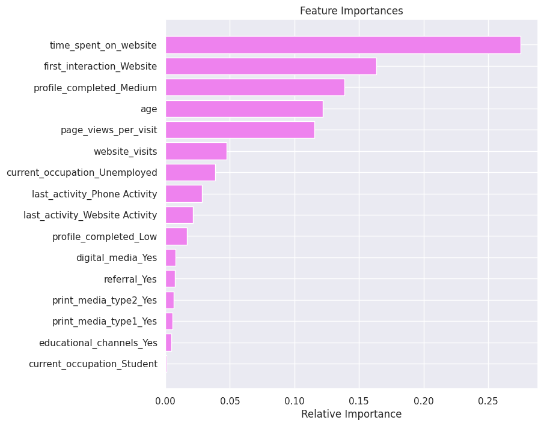

```python
# Importance of features in the tree building
importances0 = model_dt.feature_importances_
indices = np.argsort(importances0)

plt.figure(figsize=(8, 8))
plt.title("Feature Importances")
plt.barh(range(len(indices)), importances0[indices], color="violet", align="center")
plt.yticks(range(len(indices)), [feature_names[i] for i in indices])
plt.xlabel("Relative Importance")
plt.show()
```

Here we see that almost all variables have an effect on the model, which is likely due to the over-fitting.

- Time Spent on website is the most important variable

## Do we need to prune the tree?

Yes, at first glance it seems that we will need to prune the tree due to overfitting. Further analysis will explain whether or not the pruned tree performs better than the original model.

##### Pruned Tree 1

```python
# Choose the type of classifier.
estimator = DecisionTreeClassifier(random_state=1)

# Grid of parameters to choose from
parameters = {
    "max_depth": np.arange(1,100,10),
    "max_leaf_nodes": [50, 75, 150, 250],
    "min_samples_split": [10, 30, 50, 70],
}
# Run the grid search
grid_obj = GridSearchCV(estimator, parameters, cv=5,scoring='recall',n_jobs=-1)
grid_obj = grid_obj.fit(X_train, y_train)

# Set the clf to the best combination of parameters
estimator = grid_obj.best_estimator_

# Fit the best algorithm to the data.
estimator.fit(X_train, y_train)
```

```
DecisionTreeClassifier(max_depth=21, max_leaf_nodes=50, min_samples_split=10,
                       random_state=1)
```

```
              precision    recall  f1-score   support

         0.0       0.92      0.94      0.93      2058
         1.0       0.85      0.81      0.83       892

    accuracy                           0.90      2950
   macro avg       0.89      0.88      0.88      2950
weighted avg       0.90      0.90      0.90      2950
```

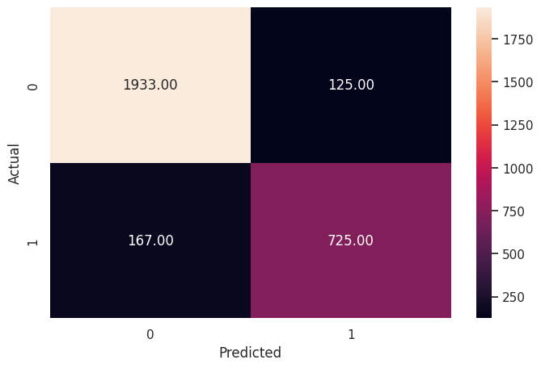

```python
# Evaluating performance of Prune tree 1 on the training dataset
dt_tuned = estimator.predict(X_train)
metrics_score(y_train,dt_tuned)
```

- Here we see that on the training data set we have reduced overfitting, however, our recall score has decreased to 81%
- Since the model is still build on this data set we will evaluate the performance on our random test sample

```
              precision    recall  f1-score   support

         0.0       0.88      0.89      0.89       883
         1.0       0.74      0.72      0.73       382

    accuracy                           0.84      1265
   macro avg       0.81      0.81      0.81      1265
weighted avg       0.84      0.84      0.84      1265
```

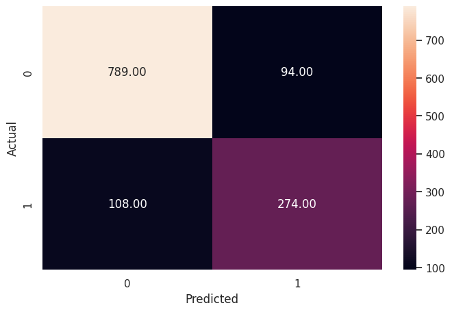

```python
# Evaluating performance of Prune Tree 1 on the test dataset
y_pred_tuned = estimator.predict(X_test)
metrics_score(y_test,y_pred_tuned)
```

- As we can see above, our Pruned tree has increased the performance on the test data, which is a representative sample of the population
- The new recall score is 72%

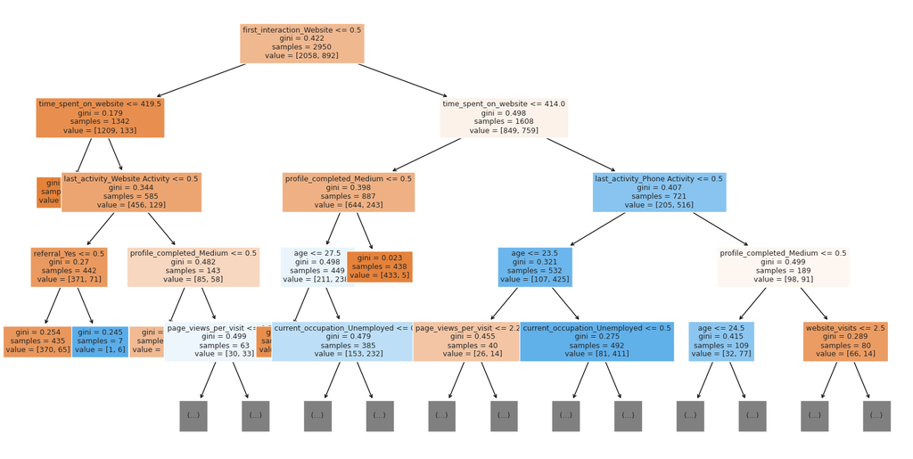

```python
# Visualizing the Pruned Decision Tree

feature_names = list(X_train.columns)
plt.figure(figsize=(20, 10))
out = tree.plot_tree(
    estimator,
    max_depth=4,
    feature_names=feature_names,
    filled=True,
    fontsize=9,
    node_ids=False,
    class_names=None,
)
# below code will add arrows to the decision tree split if they are missing
for o in out:
    arrow = o.arrow_patch
    if arrow is not None:
        arrow.set_edgecolor("black")
        arrow.set_linewidth(1)
plt.show()
```

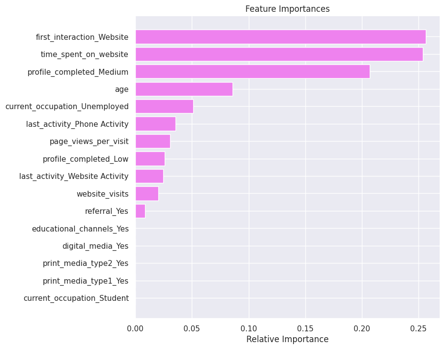

```python
# Importance of features in the tree building
importances = estimator.feature_importances_
indices = np.argsort(importances)

plt.figure(figsize=(8, 8))
plt.title("Feature Importances")
plt.barh(range(len(indices)), importances[indices], color="violet", align="center")
plt.yticks(range(len(indices)), [feature_names[i] for i in indices])
plt.xlabel("Relative Importance")
plt.show()
```

- As we examined in the EDA the marketing channels had little effect on this model
- first interaction was the most important

##### Pruned Tree 2

```python
# Choose the type of classifier.
estimator2 = DecisionTreeClassifier(random_state=1)

# Grid of parameters to choose from
parameters = {
    "max_depth": np.arange(1,5,1),
    "max_leaf_nodes": [25, 50, 100, 150],
    "min_samples_split": [5, 15, 25, 35],
}
# Run the grid search
grid_obj = GridSearchCV(estimator2, parameters, cv=5,scoring='recall',n_jobs=-1)
grid_obj = grid_obj.fit(X_train, y_train)

# Set the clf to the best combination of parameters
estimator2 = grid_obj.best_estimator_

# Fit the best algorithm to the data.
estimator2.fit(X_train, y_train)
```

```
DecisionTreeClassifier(max_depth=4, max_leaf_nodes=25, min_samples_split=5,
                       random_state=1)
```

```
              precision    recall  f1-score   support

         0.0       0.93      0.86      0.89      2058
         1.0       0.72      0.85      0.78       892

    accuracy                           0.85      2950
   macro avg       0.82      0.85      0.84      2950
weighted avg       0.87      0.85      0.86      2950
```

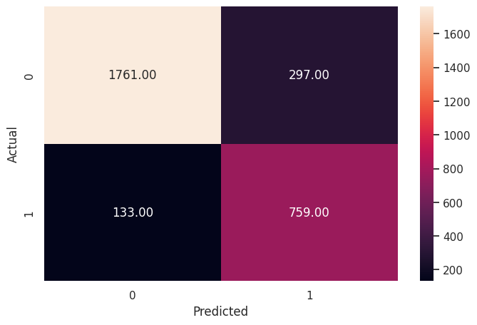

```python
# Evaluating performance of Prune tree 2 on the training dataset
dt_tuned2 = estimator2.predict(X_train)
metrics_score(y_train,dt_tuned2)
```

- Here we see that on the training data set we have reduced overfitting further and even increased our recall score to 85%
- Since the model is still build on this data set we will evaluate the performance on our random test sample

```
              precision    recall  f1-score   support

         0.0       0.91      0.82      0.86       883
         1.0       0.66      0.82      0.73       382

    accuracy                           0.82      1265
   macro avg       0.79      0.82      0.80      1265
weighted avg       0.84      0.82      0.82      1265
```

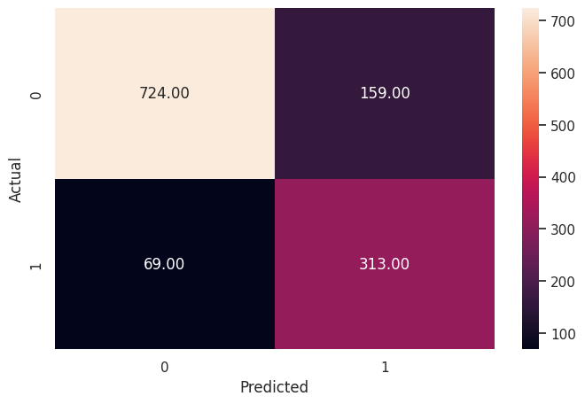

```python
# Evaluating performance of Prune Tree 2 on the test dataset
y_pred_tuned2 = estimator2.predict(X_test)
metrics_score(y_test,y_pred_tuned2)
```

- As we can see above, our Pruned tree 2 has significantly increased the performance on the test data, which is a representative sample of the population
- The new recall score is 82%

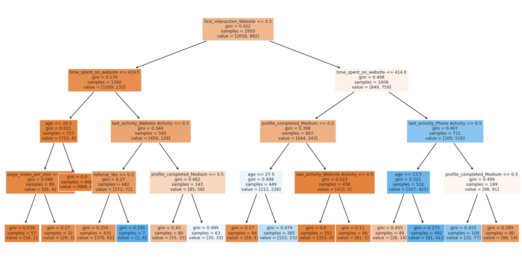

```python
# Visualizing the Pruned Decision Tree

feature_names = list(X_train.columns)
plt.figure(figsize=(20, 10))
out = tree.plot_tree(
    estimator2,
    max_depth=4,
    feature_names=feature_names,
    filled=True,
    fontsize=9,
    node_ids=False,
    class_names=None,
)
# below code will add arrows to the decision tree split if they are missing
for o in out:
    arrow = o.arrow_patch
    if arrow is not None:
        arrow.set_edgecolor("black")
        arrow.set_linewidth(1)
plt.show()
```

- Based on the visualized tree we can see that first interaction with the website was the first key classifier in our decision tree.
- At depth 4, there is an effect of page views per visit which was one of the variables for which we removed outliers so there is a possibility that this could be affected.
- Overall, the model seems to be performing well. Some variables that pose a risk to this tree are `time spent on website`, `last activity`, `page views per visit`, and `profile completed` as they depend on a duration of the lead being active in order to be measured. Defining a duration of time for measurement could help to standardize the measurement of these variables and ensure that they are a cause and not an effect

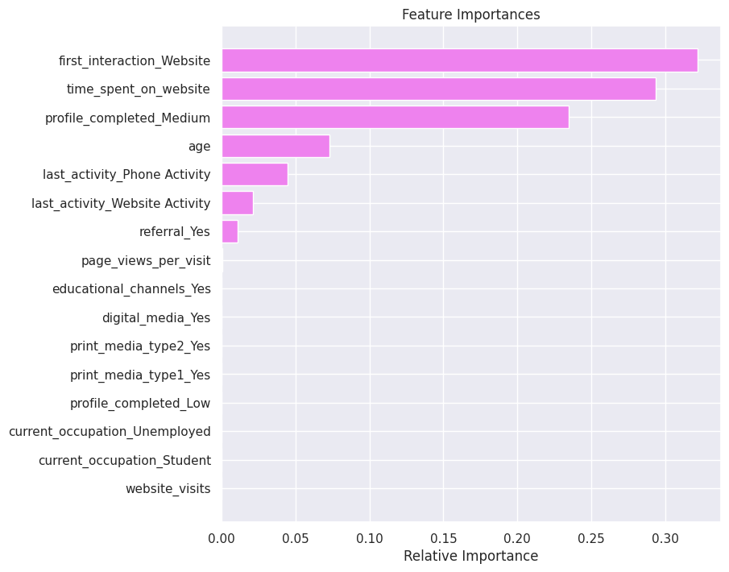

```python
# Importance of features in the tree building
importances2 = estimator2.feature_importances_
indices = np.argsort(importances2)

plt.figure(figsize=(8, 8))
plt.title("Feature Importances")
plt.barh(range(len(indices)), importances2[indices], color="violet", align="center")
plt.yticks(range(len(indices)), [feature_names[i] for i in indices])
plt.xlabel("Relative Importance")
plt.show()
```

- In this pruned model we further reduced the importances of continuous variables such as page views and website visits
- the most important features are
  1. First Interaction
  2. Time Spent
  3. Profile Completion

## Building a Random Forest model

##### Random Forest Base Model

```python
# Building the Random Forest model
rf_estimator = RandomForestClassifier( random_state = 1)

rf_estimator.fit(X_train, y_train)
```

```
RandomForestClassifier(random_state=1)
```

```
              precision    recall  f1-score   support

         0.0       1.00      1.00      1.00      2058
         1.0       1.00      1.00      1.00       892

    accuracy                           1.00      2950
   macro avg       1.00      1.00      1.00      2950
weighted avg       1.00      1.00      1.00      2950
```

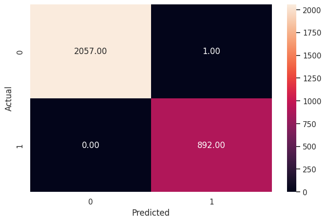

```python
# Evaluating the performance of the base model on the training data

y_pred_train_rf = rf_estimator.predict(X_train)

metrics_score(y_train, y_pred_train_rf)
```

- Similar to our Base Case Decision Tree, the Random Forest appears to be over-fitting to the training data set with 100% Recall and only 1 error (False Positive)

```
              precision    recall  f1-score   support

         0.0       0.88      0.91      0.90       883
         1.0       0.78      0.72      0.75       382

    accuracy                           0.85      1265
   macro avg       0.83      0.82      0.82      1265
weighted avg       0.85      0.85      0.85      1265
```

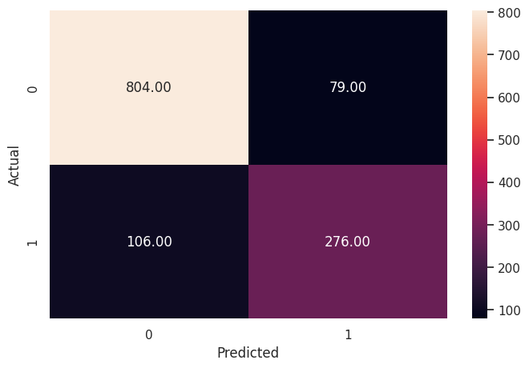

```python
# Evaluate the Random Forest Model against the test set

y_pred_test_rf = rf_estimator.predict(X_test)

metrics_score(y_test, y_pred_test_rf)
```

The Base RF Model appears to be performing well with 72% Recall compared to the original DT Model with 69% Recall.

- Pruning may help to reduce the over-fitting to the training data.

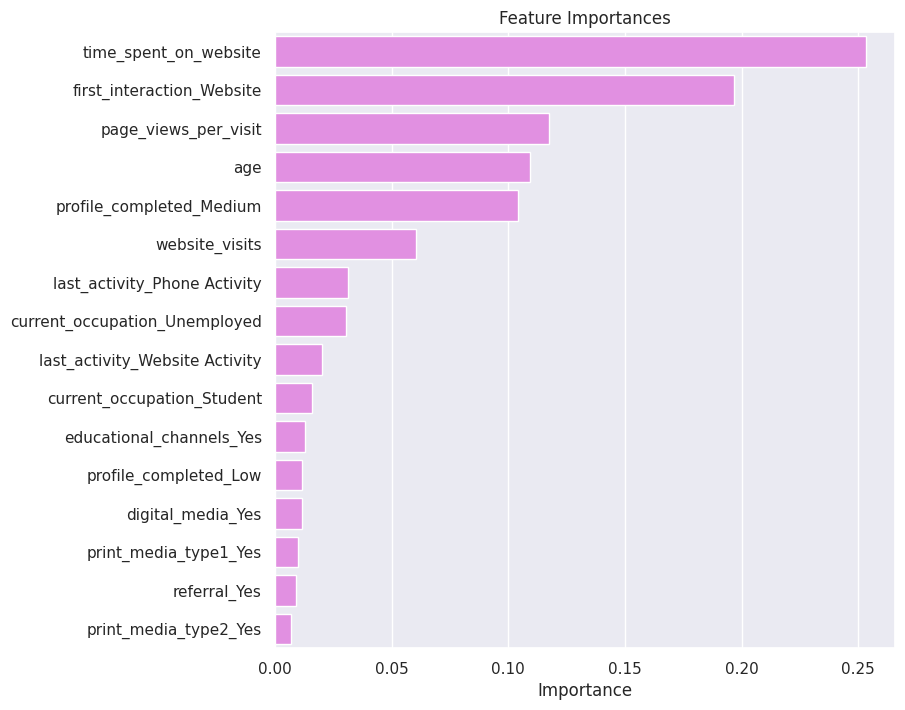

```python
importances = rf_estimator.feature_importances_

columns = X_train.columns

importance_df = pd.DataFrame(importances, index = columns, columns = ['Importance']).sort_values(by = 'Importance', ascending = False)


plt.figure(figsize=(8, 8))
plt.title("Feature Importances")
sns.barplot(x = importance_df.Importance, y = importance_df.index, color="violet")
```

The most important variables in this model are:

- Time spent on website
- first Interaction
- Page views per visit

It is important to know that page views is a variable with a significant number of outliers that was reduced.

## Do we need to prune the tree?

Yes, the model appears to be over-fitting to the training data and could benefit from pruning to increase recall.

```python
# Choose the type of classifier
rf_estimator_tuned = RandomForestClassifier(class_weight = {0: 0.17, 1: 0.83}, random_state = 1)

# Grid of parameters to choose from
params_rf = {
        "n_estimators": [100, 250, 500],
        "min_samples_leaf": np.arange(1, 4, 1),
        "max_features": [0.7, 0.9, 'auto'],
}


# Type of scoring used to compare parameter combinations - recall score for class 1
scorer = metrics.make_scorer(recall_score, pos_label = 1)

# Run the grid search
grid_obj = GridSearchCV(rf_estimator_tuned, params_rf, scoring = scorer, cv = 5)

grid_obj = grid_obj.fit(X_train, y_train)

# Set the classifier to the best combination of parameters
rf_estimator_tuned = grid_obj.best_estimator_
```

```python
rf_estimator_tuned.fit(X_train, y_train)
```

```
RandomForestClassifier(class_weight={0: 0.17, 1: 0.83}, max_features='auto',
                       min_samples_leaf=3, n_estimators=250, random_state=1)
```

```
              precision    recall  f1-score   support

         0.0       0.99      0.89      0.94      2058
         1.0       0.80      0.98      0.88       892

    accuracy                           0.92      2950
   macro avg       0.89      0.94      0.91      2950
weighted avg       0.93      0.92      0.92      2950
```

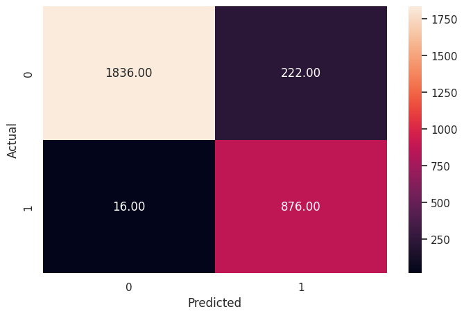

```python
# Checking performance on the training data
y_pred_train_rf_tuned = rf_estimator_tuned.predict(X_train)

metrics_score(y_train, y_pred_train_rf_tuned)
```

```
              precision    recall  f1-score   support

         0.0       0.92      0.83      0.88       883
         1.0       0.68      0.84      0.75       382

    accuracy                           0.83      1265
   macro avg       0.80      0.84      0.81      1265
weighted avg       0.85      0.83      0.84      1265
```

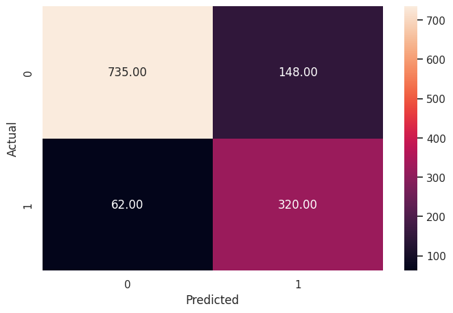

```python
# Checking performance on the test data
y_pred_test_rf_tuned = rf_estimator_tuned.predict(X_test)

metrics_score(y_test, y_pred_test_rf_tuned)
```

The pruned Random Forest Model performs the best with 84% recall. It is important to know that it is computationally exhaustive and took 4 minutes to complete, however, the results are the best out of all of the other models.

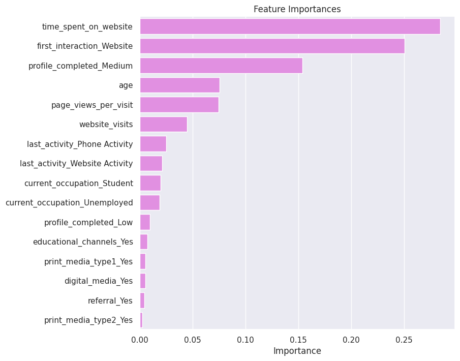

```python
importances = rf_estimator_tuned.feature_importances_

columns = X_train.columns

importance_df = pd.DataFrame(importances, index = columns, columns = ['Importance']).sort_values(by = 'Importance', ascending = False)


plt.figure(figsize=(8, 8))
plt.title("Feature Importances")
sns.barplot(x = importance_df.Importance, y = importance_df.index, color="violet")
```

The Pruned RF model decrease the importance of the page views per visit, which was transformed by taking out the outliers. The new most important features are:

1. Time Spent
2. First Interaction
3. Profile Completed

## Actionable Insights and Recommendations

*For the purposes of this analysis, I will assume that the variables and data collection process was standardized for all observations, especially for those that depend on a time duration in order to be measured. I am interested in understanding how leads are interacting with the company's digital assets to make recommendations on how to improve. Absent this assumption, I would have dropped more variables that are not immediately available the moment a lead is generated such as: `website_visits` , `time_spent_on_website`,`page_views_per_visit`*

Based on the outputs of both the Random Forest and Decision Tree Models, the 4 most important features determining conversion in the sample are: `First Interaction`, `Total Time Spent on the Website`, `Profile Completion`, and `Age`, with First interaction (DT) and Time Spent (RF) being the two most important depending on the model. The Random Forest Model performed best with 84% recall vs. the Decision Tree Model with a recall of 82%. Both of these pruned models greatly reduce the number of False Negatives, allowing ExtraaLearn to maximize the number of paying customers they can convert with the available resources.

**Final Recommendations**